# Анализ данных типа времени жизни

Литвинцев И.С

21 декабря 2017 г

## Анализ данных типа времени жизни

Day_of_clos Время закрытия артериального протока

### 1. Подготовка данных

```r
file <- "C:/Users/806263/Desktop/SPbU/Магистратура Матмех (2017-2019)/Применение статистических методов к реальным данным/Данные/baseMA.csv";
df <- read.csv(file, sep = ";", dec = ".")

df <- df[,c("Alone.Breathing", "Day_of_clos", "Sex")]
df <- na.omit(df)

head(df)
```

```
##    Alone.Breathing Day_of_clos Sex
## 13               0           9   1
## 16               1          26   1
## 18               1          12   2
## 21               0          14   2
## 22               0           8   1
## 23               0          10   1
```

```r
summary(df)
```

```
##  Alone.Breathing   Day_of_clos         Sex
##  Min.   :0.0000   Min.   : 3.00   Min.   :1.000
##  1st Qu.:0.0000   1st Qu.: 7.25   1st Qu.:1.000
##  Median :0.0000   Median :10.00   Median :1.000
##  Mean   :0.3868   Mean   :12.70   Mean   :1.321
##  3rd Qu.:1.0000   3rd Qu.:15.00   3rd Qu.:2.000
##  Max.   :1.0000   Max.   :45.00   Max.   :2.000
```

### 2. Построение оценки Каплана-Мейера

Цензурирование – это неполное наблюдение за временем ожидания отказа. Некоторые объекты не могут наблюдаться в течение полного време- ни до отказа.Известным оказывается только то, что до некоторого времени $t$ откза еще не наступил.

По определению, кривая дожития это
$$S(t) = 1-F(t)=P(\tau > t)$$
вероятность того, что отказ наступит после момента времени $t$.

При наличии цензурирования в оценке кривой дожития используется следующий принцип. Обозначим через $p_i$ вероятность того, что при условии дожить до момента $i$ отказ в этот момент так и не наступил. В качестве оценки $p_i$ будем рассматривать отношение
$$\hat{p}_i = \frac{r_i - d_i}{r_i} = 1 - \frac{d_i}{r_i},$$
где $r_i$ – число объектов с отказом не ранее момента $i$, $d_i$ – число отказов в момент $i$. Считаем что $r_1=n$. Тогда
$$P(\tau > t_i)=P(\tau > t_{i-1})P(\tau > t_i | \tau > t_{i-1})=P(\tau > t_{i-1})p_i = p_1p_2 \ldots p_i,$$
т.к. $P(\tau > 0)=1$. Следовательно,
$$\hat{P}(\tau > t_i )=\frac{r_1-d_1}{r_1} \frac{r_2 - d_2}{r_2}\ldots\frac{r_i-d_i}{r_i}.$$

Обозначим через
$$h_i = \frac{d_i}{r_i}$$
функцию интенсивности или условную вероятность погибуть в момент $i$. Оценка кривой дожития, выраженная через интенсивности, носит название функции дожития Каплана-Мейера:
$$\hat{S}(t_i)=\hat{P}(\tau > t_i )=\prod_{j=1}^{i}(1-h_j).$$
Пользуясь соотношением $r_{i+1}=r_i-d_i$, построим оценку функции дожития Каплана-Мейера

Отсортируем данные по возрастанию

```r
n <- nrow(df)

df <- df[order(df$Day_of_clos, decreasing = F), ]

num.of.repeat <- table(df$Day_of_clos)
groups <- split(df$Alone.Breathing, df$Day_of_clos)
times <- unique(df$Day_of_clos)
df.times <- data.frame()
for(i in 1:length(times)){
  t <- times[i]
  censor <- sum(groups[[as.character(t)]])
  df.times[as.character(t), "d"] <- num.of.repeat[i] - censor
  df.times[as.character(t), "z"] <- censor
}

df.times[1, "r"] <- n
for(i in 2:length(times)){
  df.times[i, "r"] <- df.times[i-1, "r"] - df.times[i-1, "d"] - df.times[i-1, "z"]
}

df.times$"p" <- 1 - df.times$d/df.times$r

df.times[1, "S"] <- df.times[1, "p"]
for(i in 2:length(times)){
  df.times[i, "S"] <- df.times[i-1, "S"] *df.times[i, "p"]
}

df.times
```

```
##     d z   r         p         S
## 3   1 0 106 0.9905660 0.9905660
## 5   2 2 105 0.9809524 0.9716981
## 6   1 7 101 0.9900990 0.9620773
## 7   7 7  93 0.9247312 0.8896629
## 8   9 3  79 0.8860759 0.7883089
## 9   5 1  67 0.9253731 0.7294799
## 10 10 3  61 0.8360656 0.6098930
## 11  4 2  48 0.9166667 0.5590686
## 12  3 4  42 0.9285714 0.5191351
## 13  3 0  35 0.9142857 0.4746378
## 14  2 0  32 0.9375000 0.4449730
## 15  4 0  30 0.8666667 0.3856432
## 16  3 1  26 0.8846154 0.3411459
## 17  2 2  22 0.9090909 0.3101327
## 19  1 0  18 0.9444444 0.2929031
## 20  2 2  17 0.8823529 0.2584439
## 21  1 1  13 0.9230769 0.2385636
## 23  1 1  11 0.9090909 0.2168760
## 26  0 1   9 1.0000000 0.2168760
## 27  1 0   8 0.8750000 0.1897665
## 28  0 1   7 1.0000000 0.1897665
## 29  0 1   6 1.0000000 0.1897665
## 30  0 1   5 1.0000000 0.1897665
## 31  0 1   4 1.0000000 0.1897665
## 41  1 0   3 0.6666667 0.1265110
## 44  1 0   2 0.5000000 0.0632555
## 45  1 0   1 0.0000000 0.0000000
```

### 3. Доверительный интервал выживаемости

Оценку точности приближения кривой выживаемости дает стандартная ошибка выживаемости, ее можно рассчитать по формуле Гринвуда:
$$D(\hat{S}_i)=\hat{S}_i^2 \sum_{j=1}^{i} \frac{d_j}{r_j(r_j - d_j)}, \qquad \sigma_{\hat{S}_i}=\sqrt{D(\hat{S}_i)}$$

```r
d <- df.times$d
r <- df.times$r
S <- df.times$S
S.sq <- df.times$S*df.times$S

frac <- d/(r*(r-d))
D <- S.sq*cumsum(frac)
sigma <- sqrt(D)
```

Доверительный интервал выживаемости в момент времени $t$ с доверительной вероятностью $1-\alpha$ определяется так:
$$\hat{S}_i - \sigma_{\hat{S}_i} \Phi_{\alpha} < S(t) < \hat{S}_i + \sigma_{\hat{S}_i} \Phi_{\alpha},$$
где $\Phi_{\alpha}$ – квантиль нормального стандартного распределения. Пусть $\alpha=0.025$.

```r
alpha <- 0.025
CI.low <- S - sigma*qnorm(1-alpha)
CI.up <- S + sigma*qnorm(1-alpha)
```

### 4. Оценка параметра постоянного риска

Условная вероятность гибели в момент времени $t$ выражается функцией интенсивности
$$h(t)=\frac{f(t)}{S(t)}=-\frac{S'(t)}{S(t)}=-(\ln S(t))'= H'(t)$$
Минус логарифм от функции надежности называется функцией риска:
$$H(t)=-\ln S(t), \qquad S(t)=e^{-H(t)}=e^{-\int_0^t h(u)du}$$
Рассмотрим $h(t)=\rho$ постоянную функцию риска. Тогда
$$H(t)=-\int_0^t h(u)du=\rho t$$
Оценим параметр постоянного риска $\rho$ по формуле
$$\hat{\rho}=\frac{m}{W}=\frac{m}{\sum_{i=1}^n x_i},$$
где $m$ – общее число отказов, $W=\sum_{i=1}^n x_i$ – суммарная наработка.

```r
m <- sum(1-df$Alone.Breathing)
W <- sum(df$Day_of_clos)
rho <- m/W; rho
```

```
## [1] 0.04829123
```

Нанесем непрерывную функцию дожития поверх графика оценки дожития

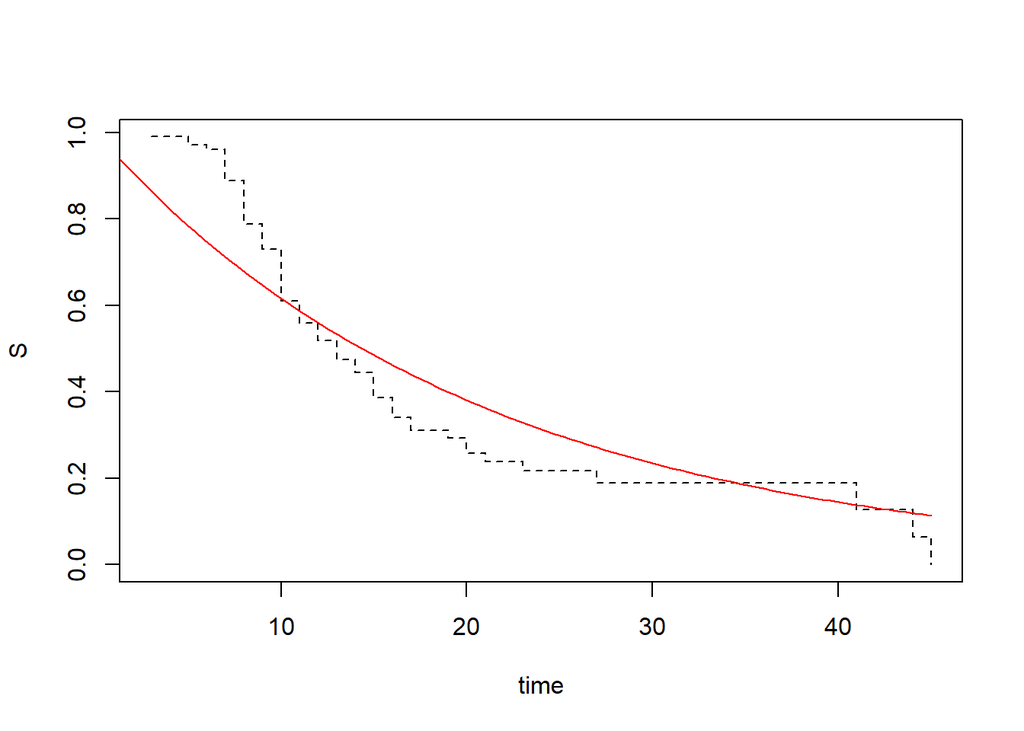

```r
plot(time, S, col=1, lty=2, type="s")
curve(exp(-rho*x), from=0, to=max(time), add=TRUE, col=2)
```

### 5. Сравнение кривых дожития у мальчиков и девочек.

Статистики, используемые для проверки гипотезы однородности, можно получить из одной таблицы. Для упрощения рассмотрим нецензурированные данные. Обозначим через $d_{0i}$ и $d_{1i}$ количестов отказов в группе 0 и 1 в момент врмени $i$, через $d_i = d_{0i}+d_{1i}$ число отказов в обеих группах, через $r_{0i}$ и $r_{1i}$ количество доживших до момента $i$ в группах 0 и 1 соответственно.

Найдем

```r
df <- df[order(df$Day_of_clos, decreasing = F), ]

sex.groups <- split(df[, -2], df$Day_of_clos)
groups <- split(df$Alone.Breathing, df$Day_of_clos)

times <- unique(df$Day_of_clos)
df.times <- data.frame()
for(i in 1:length(times)){
  t <- times[i]
  event <- sum(groups[[as.character(t)]])
  index <- sex.groups[[as.character(t)]]$Sex == 1
  d1 <-  sum(sex.groups[[as.character(t)]]$Alone.Breathing[index])
  d2 <- event - d1
  df.times[as.character(t), "d"] <- event; #num.of.repeat[i]-event
  df.times[as.character(t), "d1"] <- d1
  df.times[as.character(t), "d2"] <- d2
}

df.times[1, "r"] <- n
df.times[1, "r1"] <- sum(df$Sex == 1)
df.times[1, "r2"] <- sum(df$Sex == 2)
for(i in 2:length(times)){
  df.times[i, "r"] <- df.times[i-1, "r"] - df.times[i-1, "d"]
  df.times[i, "r1"] <- df.times[i-1, "r1"] - df.times[i-1, "d1"]
  df.times[i, "r2"] <- df.times[i-1, "r2"] - df.times[i-1, "d2"]
}

for(i in 1:length(times)){
  r <- df.times[i, "r"]
  d <- df.times[i, "d"]
  r1 <- df.times[i, "r1"]
  r2 <- df.times[i, "r2"]
  #df.times[i, "Log-rank"] <-(d*r1*r2*(r - d))/(r^2*(r-1))
  df.times[i, "D_i"] <-(d*r1*r2)/(r^2)
}

df.times
```

```
##    d d1 d2   r r1 r2       D_i
## 3  0  0  0 106 72 34 0.0000000
## 5  2  1  1 106 72 34 0.4357423
## 6  7  6  1 104 71 33 1.5163646
## 7  7  4  3  97 65 32 1.5474546
## 8  3  3  0  90 61 29 0.6551852
## 9  1  0  1  87 58 29 0.2222222
## 10 3  2  1  86 58 28 0.6587345
## 11 2  2  0  83 56 27 0.4389607
## 12 4  3  1  81 54 27 0.8888889
## 13 0  0  0  77 51 26 0.0000000
## 14 0  0  0  77 51 26 0.0000000
## 15 0  0  0  77 51 26 0.0000000
## 16 1  0  1  77 51 26 0.2236465
## 17 2  1  1  76 51 25 0.4414820
## 19 0  0  0  74 50 24 0.0000000
## 20 2  1  1  74 50 24 0.4382761
## 21 1  1  0  72 49 23 0.2173997
## 23 1  0  1  71 48 23 0.2190042
## 26 1  1  0  70 48 22 0.2155102
## 27 0  0  0  69 47 22 0.0000000
## 28 1  1  0  69 47 22 0.2171813
## 29 1  0  1  68 46 22 0.2188581
## 30 1  0  1  67 46 21 0.2151927
## 31 1  1  0  66 46 20 0.2112029
## 41 0  0  0  65 45 20 0.0000000
## 44 0  0  0  65 45 20 0.0000000
## 45 0  0  0  65 45 20 0.0000000
```

```r
E0 <- sum(df.times$d*df.times$r1/df.times$r)
d0 <- sum(df.times$d1)
D <- sum(df.times$D_i)
```

Статистика лог-рангового критерия в случае однородных кривых дожития имеет распределение хи-квадрат с одной степенью свободы:
$$\frac{(d_0 - E_0)^2}{D} \sim \chi^2(1)$$

```r
chi <- (d0 - E0)^2/D; chi
```

```
## [1] 0.05560177
```

```r
pvalue <- 1 - pchisq(chi, 1); pvalue
```

```
## [1] 0.8135877
```

p-значение достаточно большое, значит нет оснований отклолнить гипотезу однородности.

Проверим полученные результаты, построим графики кривых дожитий для мальчиков и девочек.

```r
fit.surdif <- survdiff(Surv(Day_of_clos, event=Alone.Breathing) ~ Sex, df, rho=0)
fit.surdif
```

```
## Call:
## survdiff(formula = Surv(Day_of_clos, event = Alone.Breathing) ~
##     Sex, data = df, rho = 0)
##
##        N Observed Expected (O-E)^2/E (O-E)^2/V
## Sex=1 72       27     26.6   0.00528    0.0158
## Sex=2 34       14     14.4   0.00978    0.0158
##
##  Chisq= 0  on 1 degrees of freedom, p= 0.9
```

```r
fit.surdif$var
```

```
##           [,1]      [,2]
## [1,]  8.898999 -8.898999
## [2,] -8.898999  8.898999
```

```r
fit.surdif$exp
```

```
## [1] 26.62502 14.37498
```

```r
fit.surv2 <- survfit(Surv(Day_of_clos, event=Alone.Breathing) ~ Sex, df, type="kaplan-meier")

summary(fit.surv2)
```

```
## Call: survfit(formula = Surv(Day_of_clos, event = Alone.Breathing) ~
##     Sex, data = df, type = "kaplan-meier")
##
##                 Sex=1
##  time n.risk n.event survival std.err lower 95% CI upper 95% CI
##     5     71       1    0.986  0.0140       0.9589        1.000
##     6     69       6    0.900  0.0358       0.8327        0.973
##     7     62       4    0.842  0.0437       0.7607        0.932
##     8     53       3    0.794  0.0491       0.7037        0.897
##    10     40       2    0.755  0.0541       0.6558        0.869
##    11     31       2    0.706  0.0606       0.5967        0.835
##    12     26       3    0.625  0.0695       0.5022        0.777
##    17     14       1    0.580  0.0775       0.4463        0.754
##    20     10       1    0.522  0.0889       0.3739        0.729
##    21      8       1    0.457  0.0989       0.2988        0.698
```

[output cut: 18 more lines]

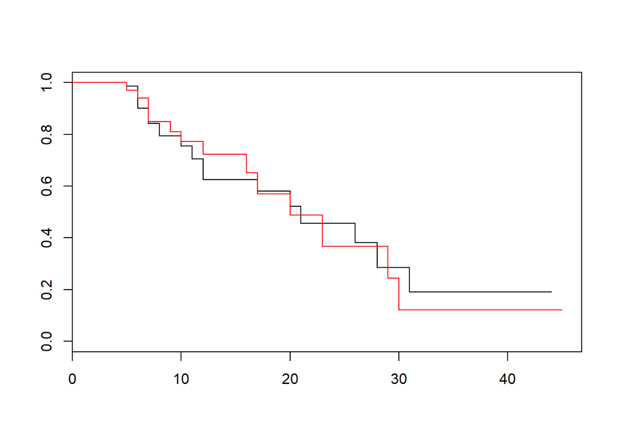

```r
plot(fit.surv2, col=1:2)
```

```r
#fit.cox <- coxph(Surv(Day_of_clos, event=Alone.Breathing) ~ Sex, df)
#summary(fit.cox)
```

### 6. Проверка реультатов

```r
#?coxph
fit.surv <- survfit(Surv(Day_of_clos, event=1-Alone.Breathing) ~ 1, df, type="kaplan-meier")

summary(fit.surv)
```

```
## Call: survfit(formula = Surv(Day_of_clos, event = 1 - Alone.Breathing) ~
##     1, data = df, type = "kaplan-meier")
##
##  time n.risk n.event survival std.err lower 95% CI upper 95% CI
##     3    106       1   0.9906 0.00939       0.9723        1.000
##     5    105       2   0.9717 0.01611       0.9406        1.000
##     6    101       1   0.9621 0.01860       0.9263        0.999
##     7     93       7   0.8897 0.03144       0.8301        0.953
##     8     79       9   0.7883 0.04228       0.7096        0.876
##     9     67       5   0.7295 0.04660       0.6436        0.827
##    10     61      10   0.6099 0.05209       0.5159        0.721
##    11     48       4   0.5591 0.05359       0.4633        0.675
##    12     42       3   0.5191 0.05450       0.4226        0.638
##    13     35       3   0.4746 0.05555       0.3773        0.597
##    14     32       2   0.4450 0.05590       0.3479        0.569
##    15     30       4   0.3856 0.05577       0.2905        0.512
##    16     26       3   0.3411 0.05493       0.2488        0.468
##    17     22       2   0.3101 0.05414       0.2203        0.437
##    19     18       1   0.2929 0.05380       0.2043        0.420
##    20     17       2   0.2584 0.05270       0.1733        0.385
##    21     13       1   0.2386 0.05226       0.1553        0.367
##    23     11       1   0.2169 0.05182       0.1358        0.346
##    27      8       1   0.1898 0.05195       0.1110        0.325
##    41      3       1   0.1265 0.06218       0.0483        0.332
##    44      2       1   0.0633 0.05447       0.0117        0.342
##    45      1       1   0.0000     NaN           NA           NA
```

Нарисуем на одном графике кривую дожития и ДИ, найденные нами (черный цвет), и кривую дожития и ДИ, полученные с помощью встроенной функции (зеленый цвет)

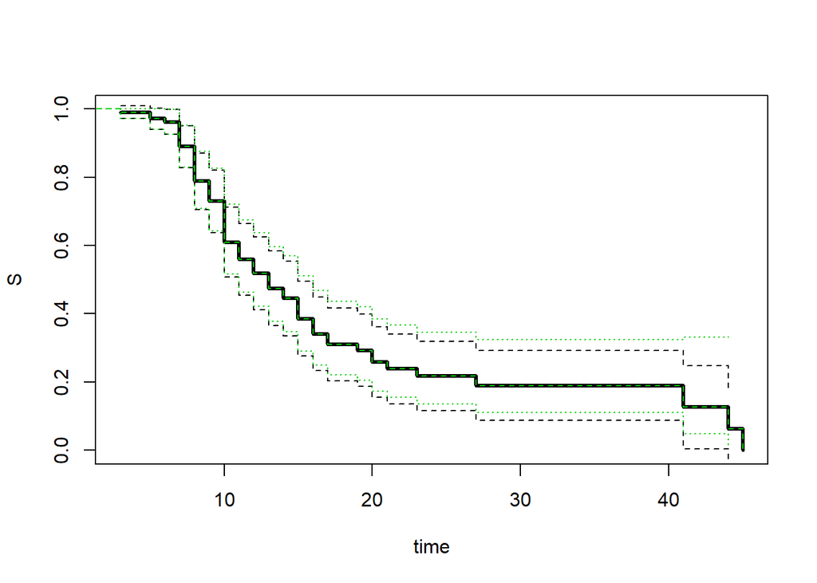

```r
# сверка значений доверительных интервалов
#data.frame(my.CI.low = CI.low,  CI.low= fit.surv$lower, my.CI.up = CI.up, CI.up=fit.surv$upper)
plot(time, S, type="s",ylim=c(0,1),lwd=3)
lines(time, CI.low,type="s",lty=2)
lines(time,CI.up,type="s",lty=2)
lines(fit.surv, mark.time=FALSE, col=3, conf.int=TRUE, lty=2)
```

Видим, что доверительные интервалы немного различаются.